## In-class worksheet 4

**Jan 25, 2018**

We will again be working with the ggplot2 package, so we need to load it:

```r
library(ggplot2) # load ggplot2 library
theme_set(theme_bw(base_size=12)) # set the default plot theme for the ggplot2 library
```

## 1. Bar plots

The `bacteria` data set contains data from tests of the presence of the bacterium *H. influenzae* in children with otitis media in the Northern Territory of Australia. We are interested in two columns of this data set: `presence` reports the presence (`y`) or absence (`n`) of the bacterium. `treatment` reports the treatment, which was `placebo`, `drug`, or `drug+` (drug plus high adherence).

```r
# download the bacteria data set:
bacteria <- read.csv("http://wilkelab.org/classes/SDS348/data_sets/bacteria.csv")
head(bacteria)
```

```
##   presence ap hilo week  ID treatment
## 1        y  p   hi    0 X01   placebo
## 2        y  p   hi    2 X01   placebo
## 3        y  p   hi    4 X01   placebo
## 4        y  p   hi   11 X01   placebo
## 5        y  a   hi    0 X02     drug+
## 6        y  a   hi    2 X02     drug+
```

Using `geom_bar()`, make a bar plot that shows the absolute number of cases with or without the bacterium, stacked on top of each other, for each treatment.

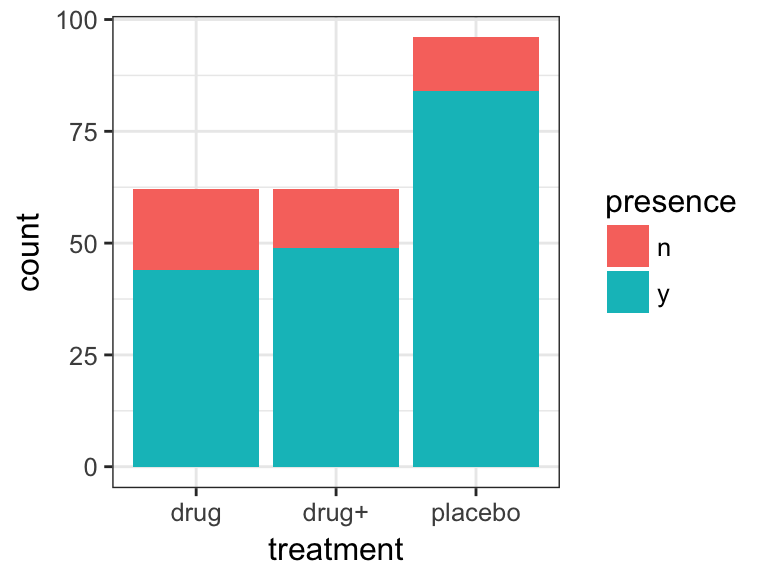

```r
ggplot(bacteria, aes(x=treatment, fill=presence)) + geom_bar()
```

Now modify the plot so that bars representing the absolute number of cases with or without the bacterium are shown side-by-side. Hint: This requires the argument `position='dodge'` in `geom_bar()`.

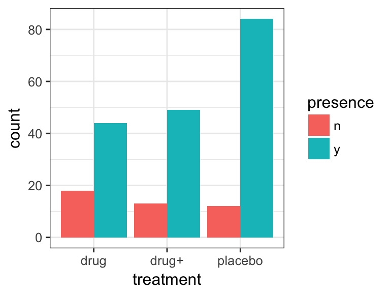

```r
ggplot(bacteria, aes(x=treatment, fill=presence)) + geom_bar(position='dodge')
```

Now modify the plot so that bars represent the relative number of cases with or without the bacterium. What is the appropriate `position` option in `geom_bar()` to achieve this effect?

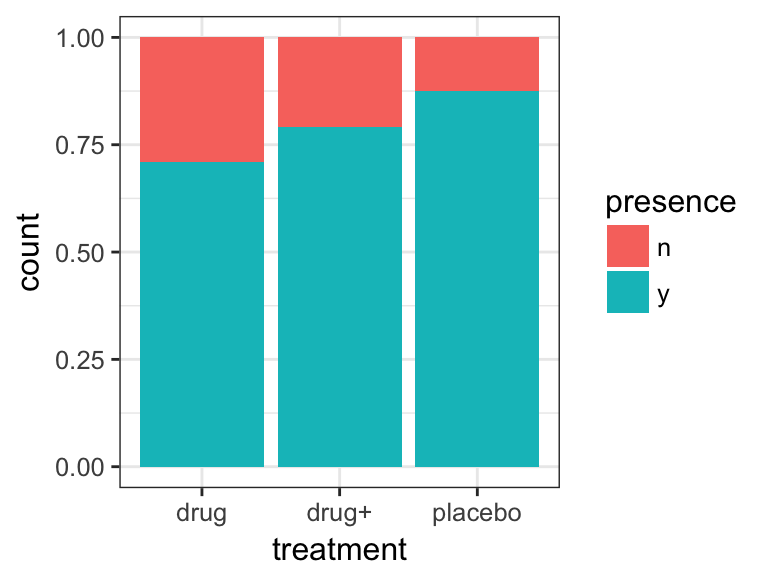

```r
ggplot(bacteria, aes(x=treatment, fill=presence)) + geom_bar(position='fill')
```

## 2. Histograms and density plots

Make a histogram plot of sepal lengths in the `iris` data set, using the default histogram settings. Then make two more such plots, with different bin widths. Use `geom_histogram()`

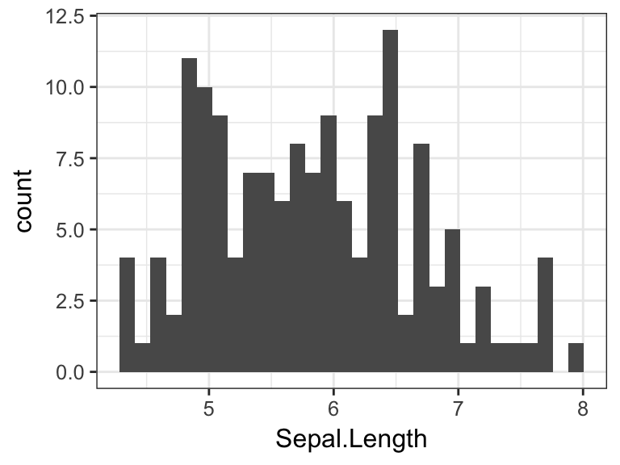

```r
# default settings
ggplot(iris, aes(x=Sepal.Length)) + geom_histogram() #
```

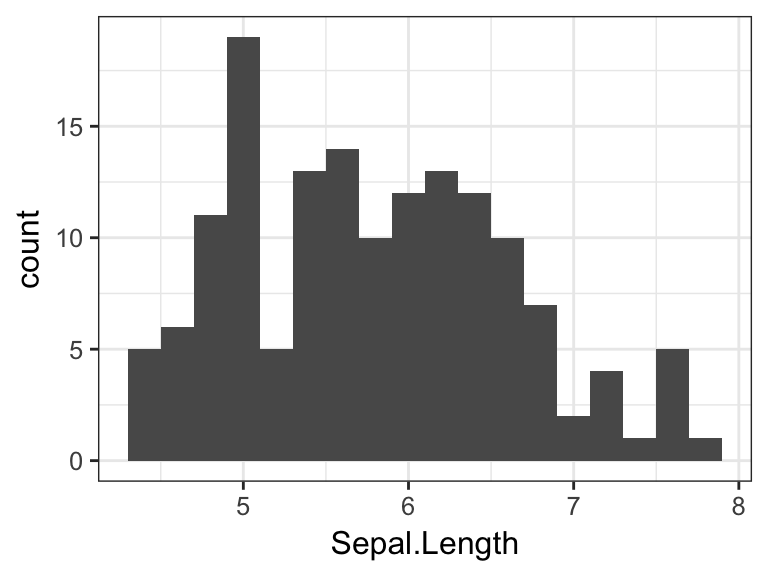

```r
# wider bins
ggplot(iris, aes(x=Sepal.Length)) + geom_histogram(binwidth=.2)
```

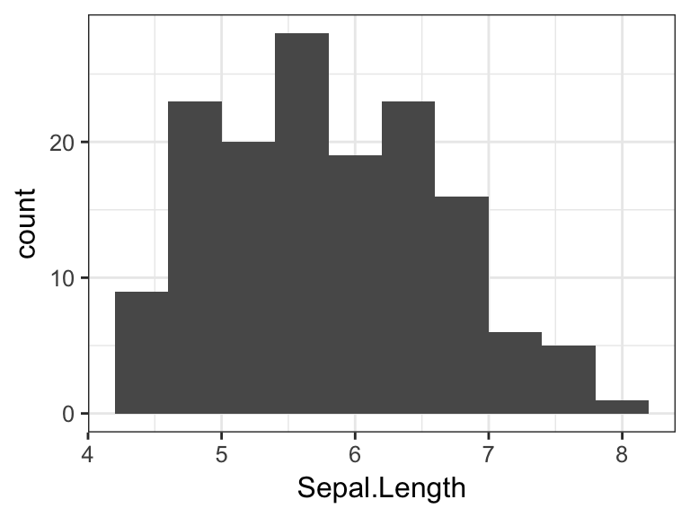

```r
# even wider bins
ggplot(iris, aes(x=Sepal.Length)) + geom_histogram(binwidth=.4)
```

Instead of `geom_histogram()`, now use `geom_density()` and fill the area under the curves by species identity.

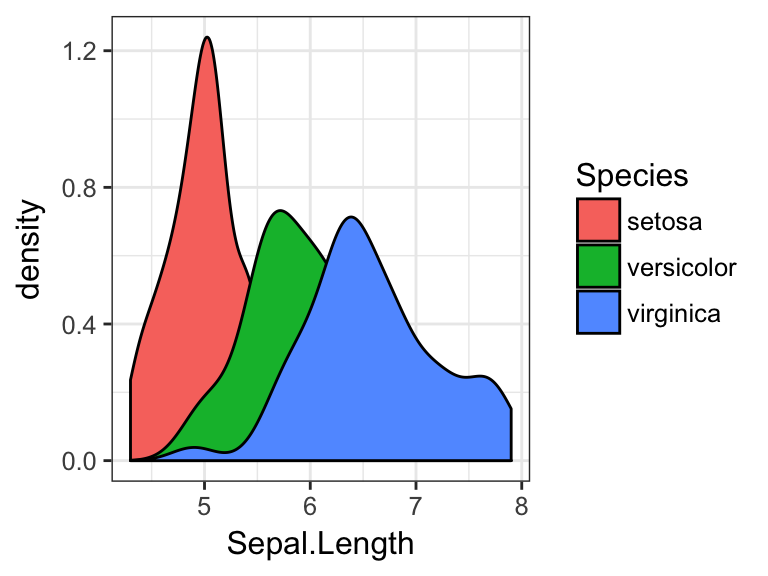

```r
ggplot(iris, aes(x=Sepal.Length, fill=Species)) + geom_density()
```

Now make the areas under the curve partially transparent, so the overlap of the various distributions becomes clearly visible.

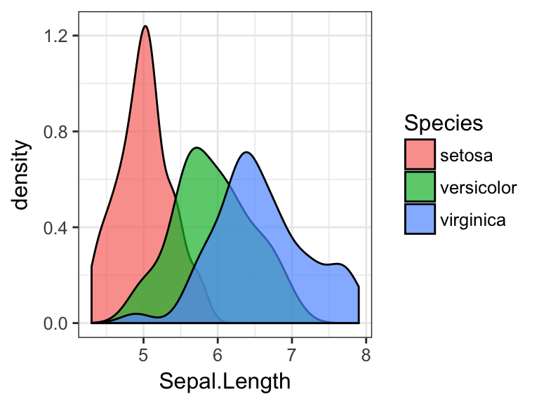

```r
ggplot(iris, aes(x=Sepal.Length, fill=Species)) + geom_density(alpha=0.7)
```

## 3. Scales

```r
library(ggplot2movies)
head(movies)
```

```
## # A tibble: 6 x 24
##                      title  year length budget rating votes    r1    r2
##                      <chr> <int>  <int>  <int>  <dbl> <int> <dbl> <dbl>
## 1                        $  1971    121     NA    6.4   348   4.5   4.5
## 2        $1000 a Touchdown  1939     71     NA    6.0    20   0.0  14.5
## 3   $21 a Day Once a Month  1941      7     NA    8.2     5   0.0   0.0
## 4                  $40,000  1996     70     NA    8.2     6  14.5   0.0
## 5 $50,000 Climax Show, The  1975     71     NA    3.4    17  24.5   4.5
## 6                    $pent  2000     91     NA    4.3    45   4.5   4.5
## # ... with 16 more variables: r3 <dbl>, r4 <dbl>, r5 <dbl>, r6 <dbl>,
## #   r7 <dbl>, r8 <dbl>, r9 <dbl>, r10 <dbl>, mpaa <chr>, Action <int>,
## #   Animation <int>, Comedy <int>, Drama <int>, Documentary <int>,
## #   Romance <int>, Short <int>
```

Now, using this data set, make a scatter plot of the number of votes (`votes`) vs. the length of the movie (`length`). Use a log scale for both the x and the y axis.

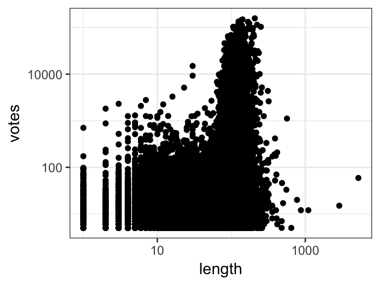

```r
ggplot(movies, aes(y=votes, x=length)) + geom_point() + scale_x_log10() + scale_y_log10()
```

Now color the points by year and use a color gradient that goes from yellow to blue. You can change the color scale using `scale_color_gradient()`.

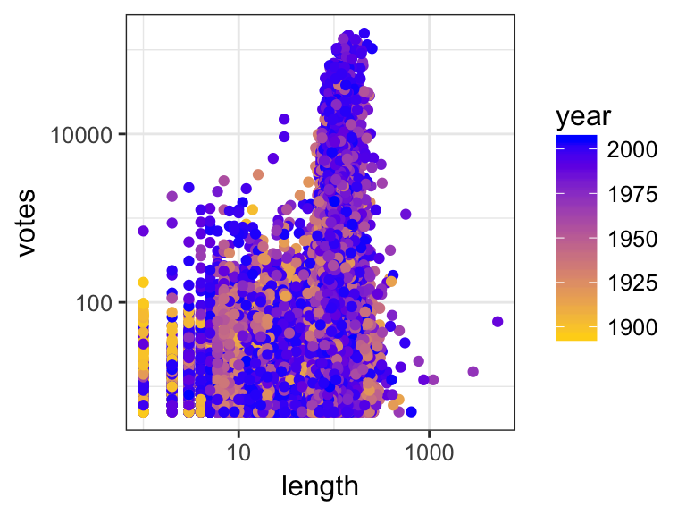

```r
ggplot(movies, aes(y=votes, x=length, color=year)) + geom_point() + scale_x_log10() + scale_y_log10() + scale_color_gradient(low='gold', high='blue')
```

Now zoom in to movies that are between 1 and 20 minutes long, using `xlim()` instead of `scale_x_log10()`.

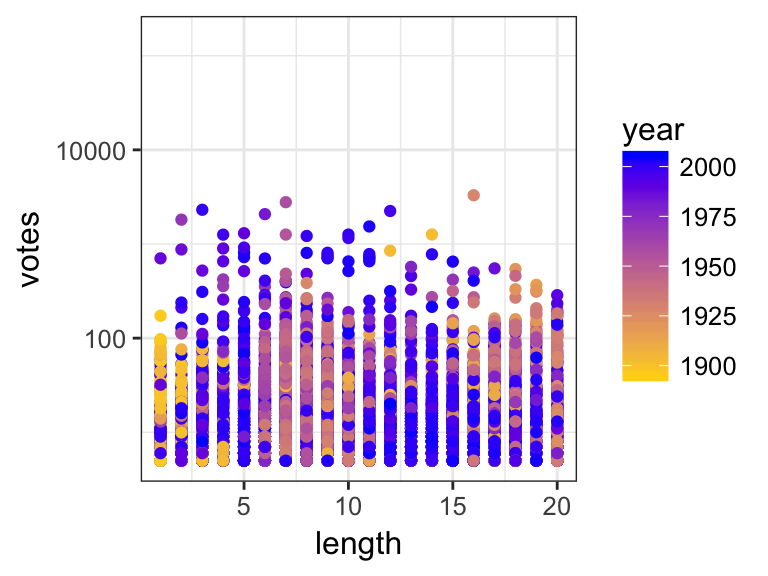

```r
ggplot(movies, aes(y=votes, x=length, color=year)) + geom_point() + xlim(1, 20) + scale_y_log10() + scale_color_gradient(low='gold', high='blue')
```

## 4. If this was easy

Take the log-log plot of `votes` vs. `length` from the `movies` data set and plot only movies that are between 1 and 20 minutes long, but keep the log scale.

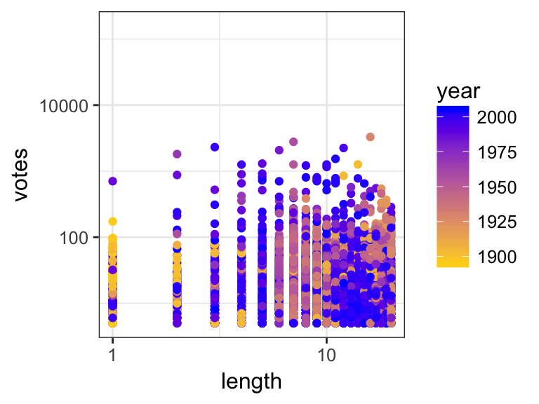

```r
ggplot(movies, aes(y=votes, x=length, color=year)) + geom_point() + scale_x_log10(limits=c(1,20)) + scale_y_log10() + scale_color_gradient(low='gold', high='blue')
```

Make a log-log plot of `votes` vs. `length` from the `movies` data set, faceted by year. Plot a trend line onto each facet, without confidence band.

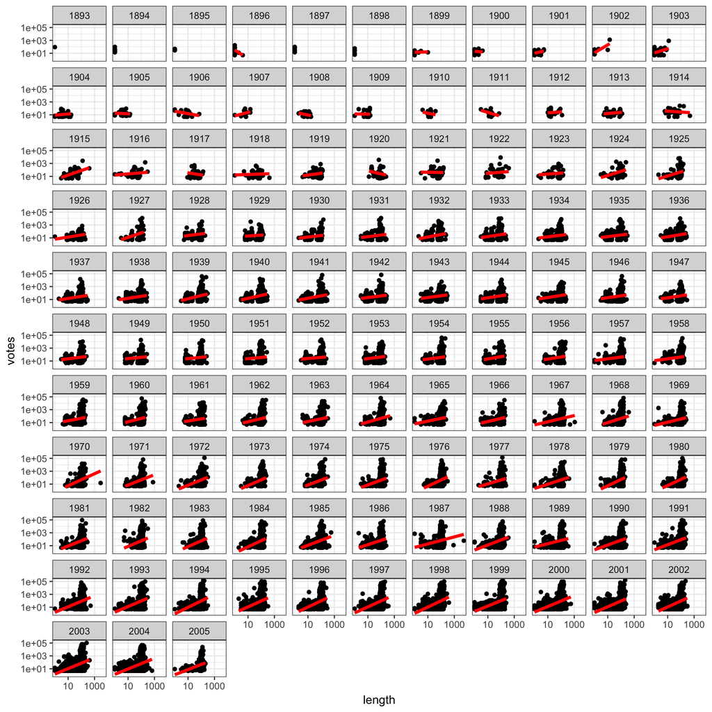

```r
ggplot(movies, aes(y=votes, x=length)) + geom_point() + geom_smooth(method='lm', se=FALSE, size=1.5, color='red') + scale_x_log10() + scale_y_log10() + facet_wrap(~year)
```

Go back to the `bacteria` dataset, make a bar plot that shows the total number of cases within each treatment, and plot the number of such cases on top of each bar.

[figure not shown]

```r
ggplot(bacteria, aes(x=treatment)) + geom_bar() + stat_count(aes(label=..count..), geom="text", vjust=-1, size=5) + ylim(0, 120)
```